# Text Mining with R - Silge

Kyla McConnell & Julia Müller

7/01/2020

# Text Analysis with R

Primary source: Text Mining with R, Julia Silge https://www.tidytextmining.com/

```r
library(tidyverse) #for various data manipulation tasks
library(tidytext) #for text mining specifically, main package in book
library(stringr) #for various text operations
library(gutenbergr) #to access full-text books that are in the public domain
library(scales) # for visualising percentages
```

```r
library(readtext) # for reading in txt files
library(wordcloud) # for creating wordclouds
```

## 1 Reading in texts

### 1.1 txt files

Here’s how you can read in one .txt file that is saved in the same location as this script (i.e. in the same folder on your computer):

```r
hf <- readtext("Adventures of Huckleberry Finn.txt")
```

If you want to read all files from a sub-folder, type the name of the folder followed by / and * to ask R to read in all files in that folder:

```r
shakes <- readtext("Shakespeare txts/*")

shakes$doc_id <- sub(".txt", "", shakes$doc_id) # this gets rid of .txt in the play titles
```

### 1.2 Book data from Project Gutenberg

- Project Gutenberg: free downloads of books in the public domain (i.e. lots of classic literature)
- Currently in a legal battle in Germany -* impossible to download via the website
- Still accessible via the R package gutenbergr by ID
- Top 100 books for inspiration (changes daily based on demand): https://www.gutenberg.org/browse/scores/top
- Catalog: https://www.gutenberg.org/catalog/

To find the id of a book (some have multiple copies):

```r
gutenberg_metadata %>%
  filter(title %in% c("Alice's Adventures in Wonderland", "Grimms' Fairy Tales", "Andersen's Fairy Tales"))
```

```
## # A tibble: 8 x 8
##   gutenberg_id title author gutenberg_autho~ language gutenberg_books~ rights
##          <int> <chr> <chr>             <int> <chr>    <chr>            <chr>
## 1           11 Alic~ Carro~                7 en       Children's Lite~ Publi~
## 2         1597 Ande~ Ander~             2298 en       Best Books Ever~ Publi~
## 3         2591 Grim~ <NA>                 NA en       <NA>             Publi~
## 4        19033 Alic~ Carro~                7 en       Children's Lite~ Publi~
## 5        19573 Alic~ Carro~                7 en       Children's Lite~ Publi~
## 6        19574 Ande~ Ander~             2298 en       Harvard Classic~ Publi~
## 7        20027 Grim~ <NA>                 NA en       <NA>             Publi~
## 8        23716 Alic~ Carro~                7 en       Children's Lite~ Publi~
## # ... with 1 more variable: has_text <lgl>
```

Can also search by author name:

```r
gutenberg_works(author == "Carroll, Lewis")
```

```
## # A tibble: 18 x 8
##    gutenberg_id title author gutenberg_autho~ language gutenberg_books~ rights
##           <int> <chr> <chr>             <int> <chr>    <chr>            <chr>
##  1           11 "Ali~ Carro~                7 en       Children's Lite~ Publi~
##  2           12 "Thr~ Carro~                7 en       Children's Lite~ Publi~
##  3           13 "The~ Carro~                7 en       Children's Lite~ Publi~
##  4          620 "Syl~ Carro~                7 en       <NA>             Publi~
##  5          651 "Pha~ Carro~                7 en       <NA>             Publi~
##  6         4763 "The~ Carro~                7 en       Philosophy       Publi~
##  7        19002 "Ali~ Carro~                7 en       Children's Lite~ Publi~
##  8        28696 "Sym~ Carro~                7 en       Philosophy       Publi~
##  9        28885 "Ali~ Carro~                7 en       Banned Books fr~ Publi~
## 10        29042 "A T~ Carro~                7 en       Mathematics      Publi~
## 11        29888 "The~ Carro~                7 en       <NA>             Publi~
## 12        33582 "Rhy~ Carro~                7 en       <NA>             Publi~
## 13        35497 "Thr~ Carro~                7 en       <NA>             Publi~
## 14        35535 "Fee~ Carro~                7 en       <NA>             Publi~
## 15        36308 "Son~ Carro~                7 en       <NA>             Publi~
## 16        38065 "Eig~ Carro~                7 en       <NA>             Publi~
## 17        48630 "Syl~ Carro~                7 en       <NA>             Publi~
## 18        48795 "Syl~ Carro~                7 en       <NA>             Publi~
## # ... with 1 more variable: has_text <lgl>
```

```r
gutenberg_works(str_detect(author, "Carroll")) #if you only have a partial name
```

```
## # A tibble: 31 x 8
##    gutenberg_id title author gutenberg_autho~ language gutenberg_books~ rights
##           <int> <chr> <chr>             <int> <chr>    <chr>            <chr>
##  1           11 "Ali~ Carro~                7 en       Children's Lite~ Publi~
##  2           12 "Thr~ Carro~                7 en       Children's Lite~ Publi~
##  3           13 "The~ Carro~                7 en       Children's Lite~ Publi~
##  4          620 "Syl~ Carro~                7 en       <NA>             Publi~
##  5          651 "Pha~ Carro~                7 en       <NA>             Publi~
##  6         4763 "The~ Carro~                7 en       Philosophy       Publi~
##  7         5994 "Our~ Carro~             1906 en       Psychology       Publi~
##  8        16861 "The~ Goodw~             6978 en       <NA>             Publi~
##  9        19002 "Ali~ Carro~                7 en       Children's Lite~ Publi~
## 10        23160 "Sol~ Carro~            25719 en       Science Fiction  Publi~
## # ... with 21 more rows, and 1 more variable: has_text <lgl>
```

For more Gutenberg search options: https://ropensci.org/tutorials/gutenbergr_tutorial/

Once you found your books, download with gutenberg_download:

```r
fairytales_raw <- gutenberg_download(c(11, 2591, 1597))
```

```
## Determining mirror for Project Gutenberg from http://www.gutenberg.org/robot/harvest
```

```
## Using mirror http://aleph.gutenberg.org
```

```r
fairytales_raw
```

```
## # A tibble: 18,321 x 2
##    gutenberg_id text
##           <int> <chr>
##  1           11 "ALICE'S ADVENTURES IN WONDERLAND"
##  2           11 ""
##  3           11 "Lewis Carroll"
##  4           11 ""
##  5           11 "THE MILLENNIUM FULCRUM EDITION 3.0"
##  6           11 ""
##  7           11 ""
##  8           11 ""
##  9           11 ""
## 10           11 "CHAPTER I. Down the Rabbit-Hole"
## # ... with 18,311 more rows
```

11: Alice’s Adventures in Wonderland 2591: Grimm’s Fairytales 1597: Hans Christian Anderson’s Fairytales

### 1.3 Preparing data

- convert Gutenberg ID to a factor and replacing the ID numbers with more descriptive labels

```r
fairytales_raw$gutenberg_id <- as.factor(fairytales_raw$gutenberg_id)
fairytales_raw$gutenberg_id <- plyr::revalue(fairytales_raw$gutenberg_id,
                                              c("11" = "Alice's Adventures in Wonderland",
                                                "2591" = "Grimm's Fairytales",
                                                "1597" = "Hans Christian Anderson's Fairytales"))
```

Break: find the text of two books you would like to compare and download them with Project Gutenberg (please decide relatively quickly!)

## 2 Tidy text

- One word per row, facilitates analysis
- Token: “a meaningful unit of text, most often a word, that we are interested in using for further analysis”

### 2.1 the unnest_tokens function

- Easy to convert from full text to token per row with unnest_tokens() Syntax: unnest_tokens(df, newcol, oldcol)
- unnest_tokens() automatically removes punctuation and converts to lowercase (unless you set to_lower = FALSE)
- by default, tokens are set to words, but you can also use token = “characters”, “ngrams”, “sentences”, “lines”, “regex”, “paragraphs”, and even “tweets” (which will retain usernames, hashtags, and URLs)

```r
fairytales_tidy <- fairytales_raw %>%
  unnest_tokens(word, text)

# this keeps the information on which sentence the words came from
fairytales_raw %>%
  unnest_tokens(sentence, text, token = "sentences") %>%
  mutate(sent_nr = row_number()) %>%
  unnest_tokens(word, sentence)
```

```
## # A tibble: 184,459 x 3
##    gutenberg_id                     sent_nr word
##    <fct>                              <int> <chr>
##  1 Alice's Adventures in Wonderland       1 alice's
##  2 Alice's Adventures in Wonderland       1 adventures
##  3 Alice's Adventures in Wonderland       1 in
##  4 Alice's Adventures in Wonderland       1 wonderland
##  5 Alice's Adventures in Wonderland       1 lewis
##  6 Alice's Adventures in Wonderland       1 carroll
##  7 Alice's Adventures in Wonderland       1 the
##  8 Alice's Adventures in Wonderland       1 millennium
##  9 Alice's Adventures in Wonderland       1 fulcrum
## 10 Alice's Adventures in Wonderland       1 edition
## # ... with 184,449 more rows
```

```r
fairytales_tidy
```

```
## # A tibble: 184,459 x 2
##    gutenberg_id                     word
##    <fct>                            <chr>
##  1 Alice's Adventures in Wonderland alice's
##  2 Alice's Adventures in Wonderland adventures
##  3 Alice's Adventures in Wonderland in
##  4 Alice's Adventures in Wonderland wonderland
##  5 Alice's Adventures in Wonderland lewis
##  6 Alice's Adventures in Wonderland carroll
##  7 Alice's Adventures in Wonderland the
##  8 Alice's Adventures in Wonderland millennium
##  9 Alice's Adventures in Wonderland fulcrum
## 10 Alice's Adventures in Wonderland edition
## # ... with 184,449 more rows
```

```r
shakes_unnest <- shakes %>%
  unnest_tokens(word, text)
```

### 2.2 Removing non-alphanumeric characters

- Project Gutenberg data sometimes contains underscores to indicate italics
- str_extract is used to get rid of non-alphanumeric characters (because we don’t want to count *word* separately from word)

```r
fairytales_tidy <- fairytales_tidy %>%
  mutate(word = str_extract(word, "[a-z']+"))

shakes_unnest <- shakes_unnest %>%
  mutate(word = str_extract(word, "[a-z']+"))
```

### 2.3 Stop words

- Stop words: very common, “meaningless” function words like “the”, “of” and “to” – not usually important in an analysis (i.e. to find out that the most common word in two books you are comparing is “the”)
- tidytext has a built-in df called stop_words for English
- remove these from your dataset with anti_join

We can take a look:

```r
stop_words
```

```
## # A tibble: 1,149 x 2
##    word        lexicon
##    <chr>       <chr>
##  1 a           SMART
##  2 a's         SMART
##  3 able        SMART
##  4 about       SMART
##  5 above       SMART
##  6 according   SMART
##  7 accordingly SMART
##  8 across      SMART
##  9 actually    SMART
## 10 after       SMART
## # ... with 1,139 more rows
```

```r
fairytales_tidy <- fairytales_tidy %>%
  anti_join(stop_words)
fairytales_tidy
```

```
## # A tibble: 54,511 x 2
##    gutenberg_id                     word
##    <fct>                            <chr>
##  1 Alice's Adventures in Wonderland alice's
##  2 Alice's Adventures in Wonderland adventures
##  3 Alice's Adventures in Wonderland wonderland
##  4 Alice's Adventures in Wonderland lewis
##  5 Alice's Adventures in Wonderland carroll
##  6 Alice's Adventures in Wonderland millennium
##  7 Alice's Adventures in Wonderland fulcrum
##  8 Alice's Adventures in Wonderland edition
##  9 Alice's Adventures in Wonderland <NA>
## 10 Alice's Adventures in Wonderland chapter
## # ... with 54,501 more rows
```

Define other stop words:

```r
meaningless_words <- tibble(word = c("von", "der", "thy", "thee", "thou"))

fairytales_tidy <- fairytales_tidy %>%
  anti_join(meaningless_words)
```

This could also be used to remove character names, for example.

The stopwords package also contains lists of stopwords for other languages, so to get a list of German stopwords, you could use:

```r
library(stopwords)
stop_german <- data.frame(word = stopwords::stopwords("de"), stringsAsFactors = FALSE)
```

More info: https://cran.r-project.org/web/packages/stopwords/readme/README.html

Break: Prepare your data with the steps above. 1) Unnest tokens, 2) Remove alpha-numeric characters, 3) Remove stopwords

## 3 Analysing frequencies

### 3.1 Find most frequent words

- Easily find frequent words using count()
- Data must be in tidy format (one token per line)
- sort = TRUE to show the most frequent words first

tidy_books %>% count(word, sort = TRUE)

```r
fairytales_freq <- fairytales_tidy %>%
  group_by(gutenberg_id) %>% #including this ensures that the counts are by book and the id column is retained
  count(word, sort=TRUE)

fairytales_freq
```

```
## # A tibble: 11,214 x 3
## # Groups:   gutenberg_id [3]
##    gutenberg_id                     word       n
##    <fct>                            <chr>  <int>
##  1 Alice's Adventures in Wonderland alice    386
##  2 Grimm's Fairytales               king     278
##  3 Grimm's Fairytales               time     207
##  4 Grimm's Fairytales               day      191
##  5 Grimm's Fairytales               home     180
##  6 Grimm's Fairytales               father   161
##  7 Grimm's Fairytales               cried    153
##  8 Grimm's Fairytales               wife     150
##  9 Grimm's Fairytales               mother   144
## 10 Grimm's Fairytales               door     143
## # ... with 11,204 more rows
```

```r
shakes_freq <- shakes_unnest %>%
  group_by(doc_id) %>%
  count(word, sort = TRUE)
```

Reminder: filter can be used to look at subsets of the data, i.e. one book, all words with freq above 100, etc. (Note here that I don’t save this output)

```r
fairytales_tidy %>%
  group_by(gutenberg_id) %>%
  count(word, sort=TRUE) %>%
  filter(gutenberg_id == "Grimm's Fairytales")
```

```
## # A tibble: 4,369 x 3
## # Groups:   gutenberg_id [1]
##    gutenberg_id       word       n
##    <fct>              <chr>  <int>
##  1 Grimm's Fairytales king     278
##  2 Grimm's Fairytales time     207
##  3 Grimm's Fairytales day      191
##  4 Grimm's Fairytales home     180
##  5 Grimm's Fairytales father   161
##  6 Grimm's Fairytales cried    153
##  7 Grimm's Fairytales wife     150
##  8 Grimm's Fairytales mother   144
##  9 Grimm's Fairytales door     143
## 10 Grimm's Fairytales fell     130
## # ... with 4,359 more rows
```

#### Plotting word frequencies - bar graphs

Bar graph of top words in Grimm’s fairytales.

Basic graph:

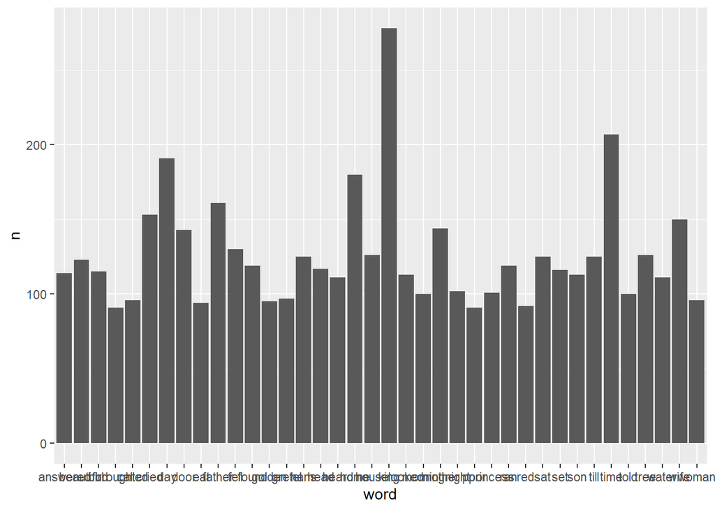

```r
fairytales_freq %>%
  filter(n>90 & gutenberg_id == "Grimm's Fairytales") %>%
  ggplot(aes(x=word, y=n)) +
  geom_col()
```

Readable labels:

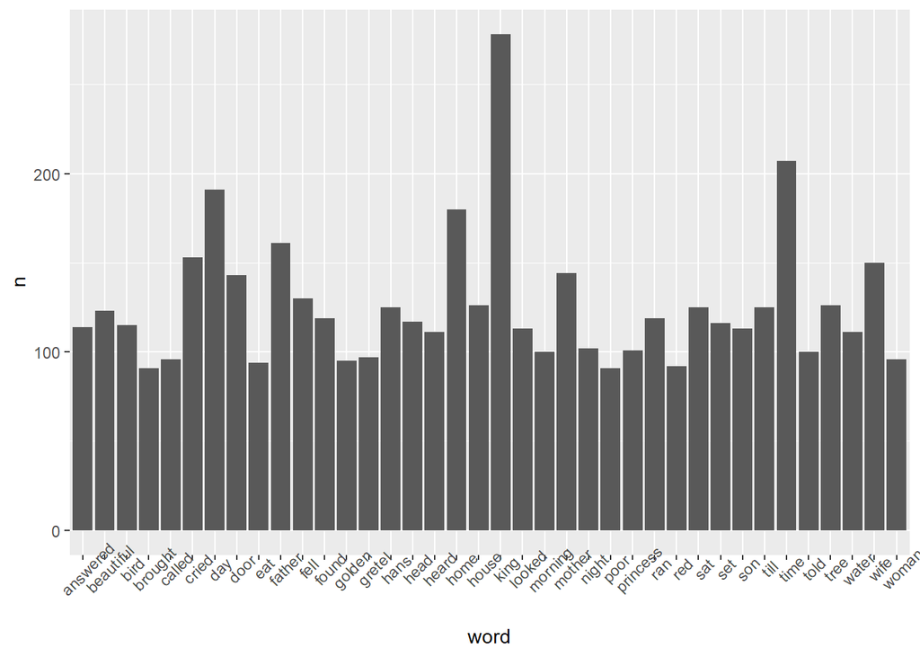

```r
fairytales_freq %>%
  filter(n>90 & gutenberg_id == "Grimm's Fairytales") %>%
  ggplot(aes(x=word, y=n)) +
  geom_col() +
  theme(axis.text.x = element_text(angle = 45))
```

Descending order:

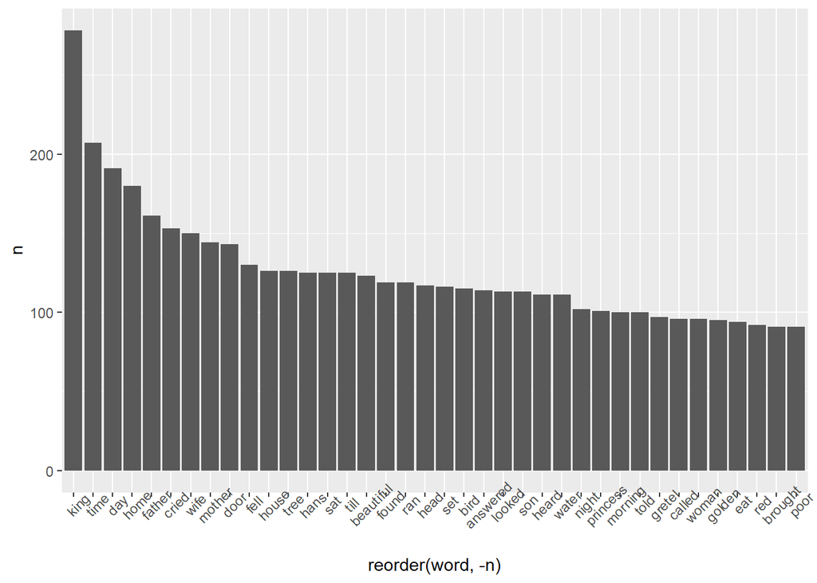

```r
fairytales_freq %>%
  filter(n>90 & gutenberg_id == "Grimm's Fairytales") %>%
  ggplot(aes(x=reorder(word, -n), y=n)) +
  geom_col() +
  theme(axis.text.x = element_text(angle = 45))
```

Axis names and colors:

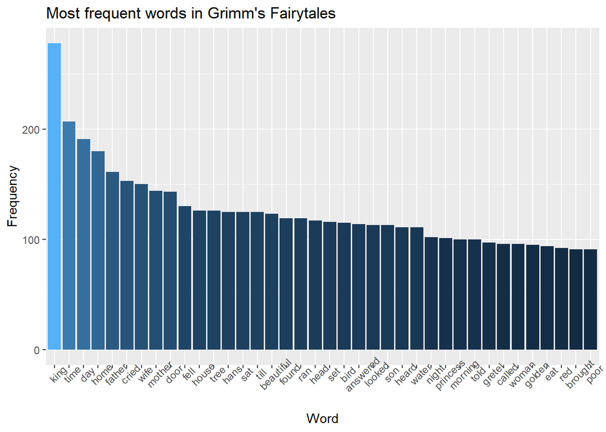

```r
fairytales_freq %>%
  filter(n>90 & gutenberg_id == "Grimm's Fairytales") %>%
  ggplot(aes(x=reorder(word, -n), y=n, fill=n)) +
  geom_col(show.legend=FALSE) +
  theme(axis.text.x = element_text(angle = 45)) +
  xlab("Word") +
  ylab("Frequency") +
  ggtitle("Most frequent words in Grimm's Fairytales")
```

Or: flip coordinate system to make more space for words

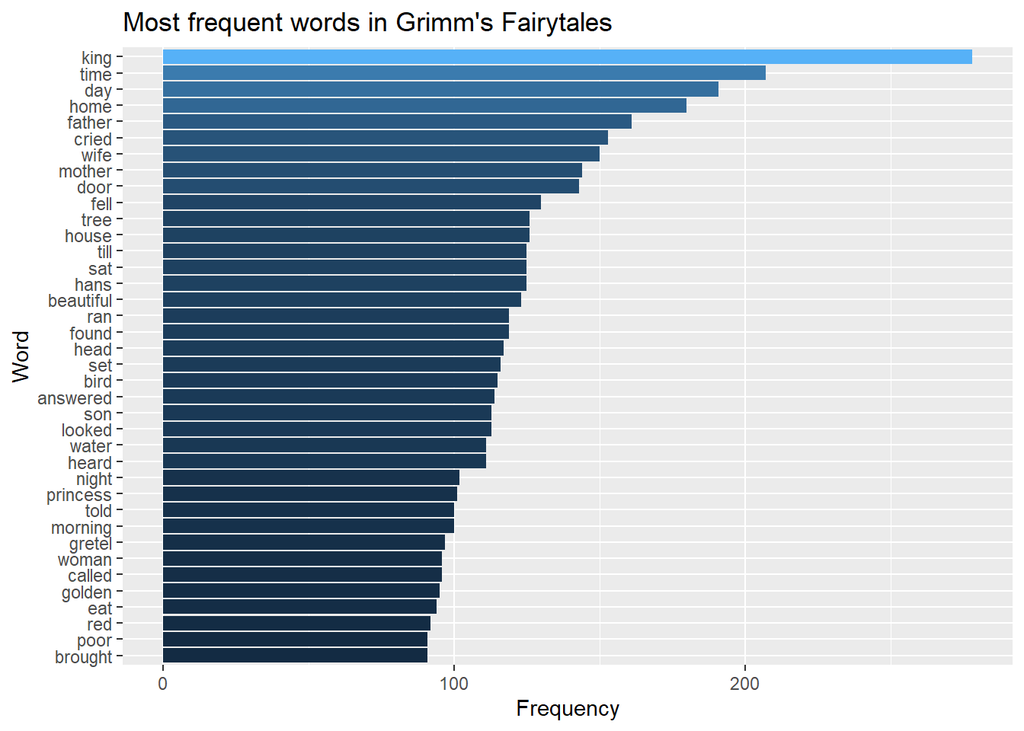

```r
fairytales_freq %>%
  filter(n>90 & gutenberg_id == "Grimm's Fairytales") %>%
  ggplot(aes(x=reorder(word, n), y=n, fill=n)) +
  geom_col(show.legend=FALSE) +
  xlab("Word") +
  ylab("Frequency") +
  ggtitle("Most frequent words in Grimm's Fairytales") +
  coord_flip()
```

### 3.2 Normalised frequency

- when comparing the frequencies of words from different texts, they are commonly normalised
- convention in corpus linguistics: report the frequency per 1 million words
- for shorter texts: per 10,000 or per 100,000 words
- calculation: raw frequency * 1,000,000 / total numbers in text

```r
# see the total number of words per play (doc_id)
shakes_freq %>%
  group_by(doc_id) %>%
  mutate(sum(n)) %>%
  distinct(doc_id, sum(n))
```

```
## # A tibble: 13 x 2
## # Groups:   doc_id [13]
##    doc_id             `sum(n)`
##    <chr>                 <int>
##  1 Hamlet                32049
##  2 Henry V               26967
##  3 King Richard III      31690
##  4 Tempest               21717
##  5 Othello               27488
##  6 King Lear             28015
##  7 Merchant of Venice    22015
##  8 Shrew                 22665
##  9 Romeo and Juliet      25959
## 10 As You Like It        23089
## 11 Julius Caesar         21044
## 12 Macbeth               17825
## 13 Midsummer             17090
```

```r
shakes_freq <- shakes_freq %>%
  na.omit() %>%
  group_by(doc_id) %>%
  mutate(pmw = n*1000000/sum(n)) %>% # creates a new column called pmw
  ungroup() %>%
  anti_join(stop_words) # removing stopwords afterwards
shakes_freq %>% select(word, pmw)
```

```
## # A tibble: 44,244 x 2
##    word        pmw
##    <chr>     <dbl>
##  1 brutus   17168.
##  2 ham      11187.
##  3 iago     12410.
##  4 romeo    11420.
##  5 thou     10648.
##  6 rosalind 11399.
##  7 king      8216.
##  8 king      9271.
##  9 lord      7395.
## 10 caesar   10985.
## # ... with 44,234 more rows
```

#### Plotting normalised frequency

Now we can plot, for example, the 20 most frequent words (by pmw).

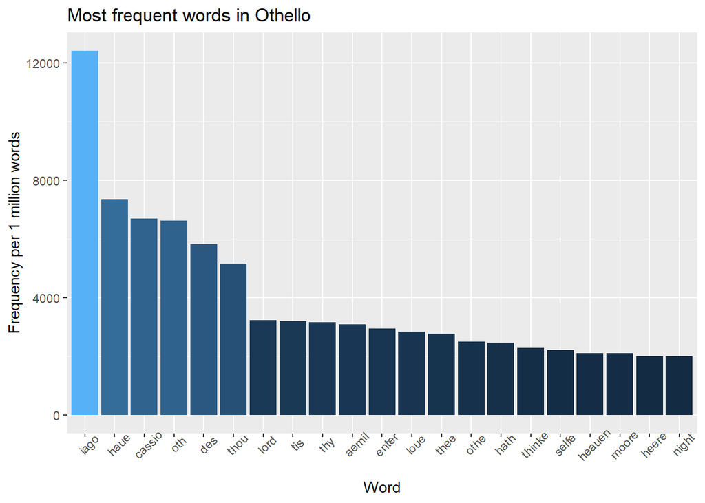

```r
shakes_freq %>%
  filter(doc_id == "Othello") %>%
  top_n(20, pmw) %>%
  ggplot(aes(x=reorder(word, -pmw), y=pmw, fill=pmw)) +
  geom_col(show.legend=FALSE) +
  theme(axis.text.x = element_text(angle = 45)) +
  xlab("Word") +
  ylab("Frequency per 1 million words") +
  ggtitle("Most frequent words in Othello")
```

Break: Gather frequency counts for your text, normalize them, and create a bar chart of most the normalized frequencies.

### 3.3 Word clouds

Let’s visualise the most frequent words in a word cloud. Here, the size indicates the frequency, with words that occur more often being displayed in a larger font size, but this can also be used to visualise e.g. normalised frequency (pmw) or length or anything else you pass to the freq = part of the command.

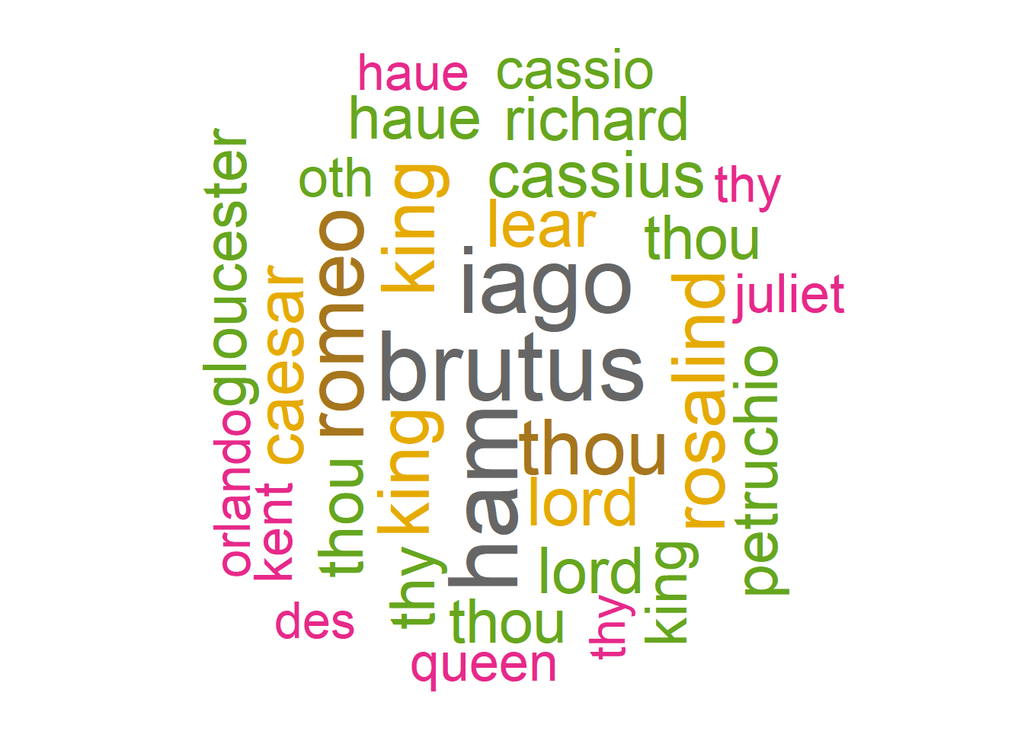

```r
wordcloud(words = shakes_freq$word, freq = shakes_freq$n,
          min.freq = 150, max.words=200, random.order=FALSE, rot.per=0.35,
          colors=brewer.pal(8, "Dark2"))
```

## 4 Comparing the vocabulary of texts

Next, we’ll create two graphs to compare the vocabulary of our texts. First, we focus on Alice’s Adventures and Anderson’s Fairytales. The newly created comp_2 data frame contains only the words and their frequencies in the two texts in two separate columns.

### Comparing two texts

```r
comp_2 <- fairytales_freq %>%
  filter(gutenberg_id == "Alice's Adventures in Wonderland"|gutenberg_id == "Hans Christian Anderson's Fairytales") %>%
  group_by(gutenberg_id) %>%
  mutate(proportion = n / sum(n)) %>% #creates proportion column (word frequency divided by overall frequency per author)
  select(-n) %>%
  spread(gutenberg_id, proportion)

head(comp_2)
```

```
## # A tibble: 6 x 3
##   word      `Alice's Adventures in Wonderla~ `Hans Christian Anderson's Fairyta~
##   <chr>                                <dbl>                               <dbl>
## 1 abandoned                        NA                                  0.0000575
## 2 abashed                          NA                                  0.000172
## 3 abide                             0.000131                          NA
## 4 abode                            NA                                  0.0000575
## 5 abroad                           NA                                  0.000115
## 6 absalon                          NA                                  0.0000575
```

Now, we can plot the words. Their placement depends on the word frequencies. Additionally, colour coding shows how different the frequencies are - darker items are more similar in terms of their frequencies, lighter-coloured ones more frequent in one text compared to the other. We’ll discuss the interpretation in more detail once we’ve created the threeway comparison.

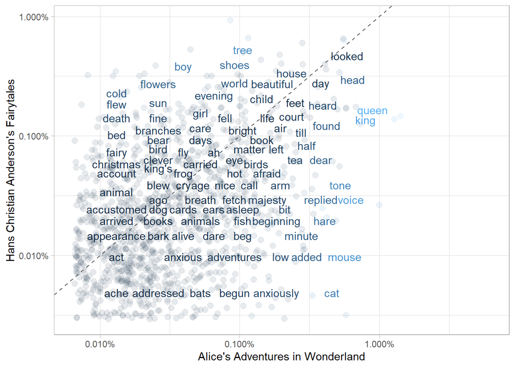

```r
ggplot(comp_2,
       aes(x = `Alice's Adventures in Wonderland`, y = `Hans Christian Anderson's Fairytales`,
           color = abs(`Alice's Adventures in Wonderland` - `Hans Christian Anderson's Fairytales`))) +
  geom_abline(color = "gray40", lty = 2) +
  geom_jitter(alpha = 0.1, size = 2.5, width = 0.3, height = 0.3) +
  geom_text(aes(label = word), check_overlap = TRUE, vjust = 1.5) +
  scale_x_log10(labels = percent_format()) +
  scale_y_log10(labels = percent_format()) +
  theme_light() +
  theme(legend.position="none") +
  labs(y = "Hans Christian Anderson's Fairytales", x = "Alice's Adventures in Wonderland")
```

### Comparing three texts

In order to compare three texts, we need to add one step to the data preparation: Grimm’s Fairytales will be the text that the other two will be compared to, so its word frequencies will be contained in the Grimm’s Fairytales column. The gutenberg_id column contains both Alice’s Adventures and Anderson’s Fairytales so we can pass this column to the facet_wrap command and create two graphs.

```r
comp_3 <- fairytales_freq %>%
  group_by(gutenberg_id) %>%
  mutate(proportion = n / sum(n)) %>% #creates proportion column (word frequency divided by overall frequency per author)
  select(-n) %>%
  spread(gutenberg_id, proportion) %>%
  gather(gutenberg_id, proportion, "Alice's Adventures in Wonderland":"Hans Christian Anderson's Fairytales") # only done for plotting

head(comp_3); unique(comp_3$gutenberg_id)
```

```
## # A tibble: 6 x 4
##   word      `Grimm's Fairytales` gutenberg_id                     proportion
##   <chr>                    <dbl> <chr>                                 <dbl>
## 1 abandoned           NA         Alice's Adventures in Wonderland  NA
## 2 abashed              0.0000342 Alice's Adventures in Wonderland  NA
## 3 abide                0.0000683 Alice's Adventures in Wonderland   0.000131
## 4 abode                0.0000683 Alice's Adventures in Wonderland  NA
## 5 abroad              NA         Alice's Adventures in Wonderland  NA
## 6 absalon             NA         Alice's Adventures in Wonderland  NA
```

```
## [1] "Alice's Adventures in Wonderland"
## [2] "Hans Christian Anderson's Fairytales"
```

The ggplot command is very similar to the one used above but facet_wrap is added to create two comparisons - Grimm’s Fairytales compared to Alice’s Adventures (left graph) and Grimm’s compared to Anderson’s fairytales (right graph):

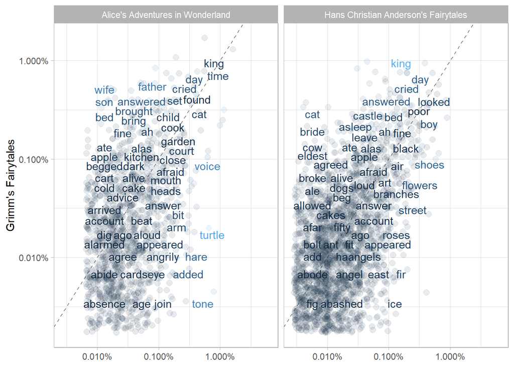

```r
ggplot(comp_3,
       aes(x = proportion, y = `Grimm's Fairytales`,
           color = abs(`Grimm's Fairytales` - proportion))) +
  geom_abline(color = "gray40", lty = 2) +
  geom_jitter(alpha = 0.1, size = 2.5, width = 0.3, height = 0.3) +
  geom_text(aes(label = word), check_overlap = TRUE) +
  scale_x_log10(labels = percent_format()) +
  scale_y_log10(labels = percent_format()) +
  theme_light() +
  facet_wrap(~ gutenberg_id, ncol = 2) +
  theme(legend.position="none") +
  labs(y = "Grimm's Fairytales", x = NULL)
```

## 5 Word and document frequencies

### 5.1 tf-idf

How can we quantify what a text/document is about? We could analyse the term frequency (tf) - how often does a term occur in a text/document. However, common words are the same in most texts, e.g. grammatical words like articles. A solution would be to instead analyse the inverse document frequency (idf) which lowers the importance of frequent words and raises the importance of rare words in documents. So it’s a measure of how important a word is to a text compared to how important it is in the collection of texts.

#### The bind_tf_idf-function

- input: format needs to be one row per token (term), per document
- one column (here: word) contains the terms/tokens
- one column (here: gutenberg_id) contains the documents

```r
fairytales_idf <- fairytales_freq %>%
  bind_tf_idf(word, gutenberg_id, n)

fairytales_idf %>%
  select(gutenberg_id, word, tf_idf) %>%
  arrange(desc(tf_idf))
```

```
## # A tibble: 11,214 x 3
## # Groups:   gutenberg_id [3]
##    gutenberg_id                         word      tf_idf
##    <fct>                                <chr>      <dbl>
##  1 Alice's Adventures in Wonderland     alice    0.0557
##  2 Alice's Adventures in Wonderland     mock     0.00808
##  3 Alice's Adventures in Wonderland     gryphon  0.00793
##  4 Alice's Adventures in Wonderland     hatter   0.00793
##  5 Hans Christian Anderson's Fairytales gerda    0.00720
##  6 Alice's Adventures in Wonderland     rabbit   0.00678
##  7 Alice's Adventures in Wonderland     dormouse 0.00563
##  8 Alice's Adventures in Wonderland     duchess  0.00563
##  9 Hans Christian Anderson's Fairytales shadow   0.00537
## 10 Hans Christian Anderson's Fairytales kay      0.00454
## # ... with 11,204 more rows
```

interpretation:

- low tf_idf if words appear in many books, high if they occur in few books
- characteristic words for documents
- so unsurprisingly, in our data, the first hits with the highest tf_idf are character names

#### Characteristic words per book

visualisation of the top 20 tf-idf words per book:

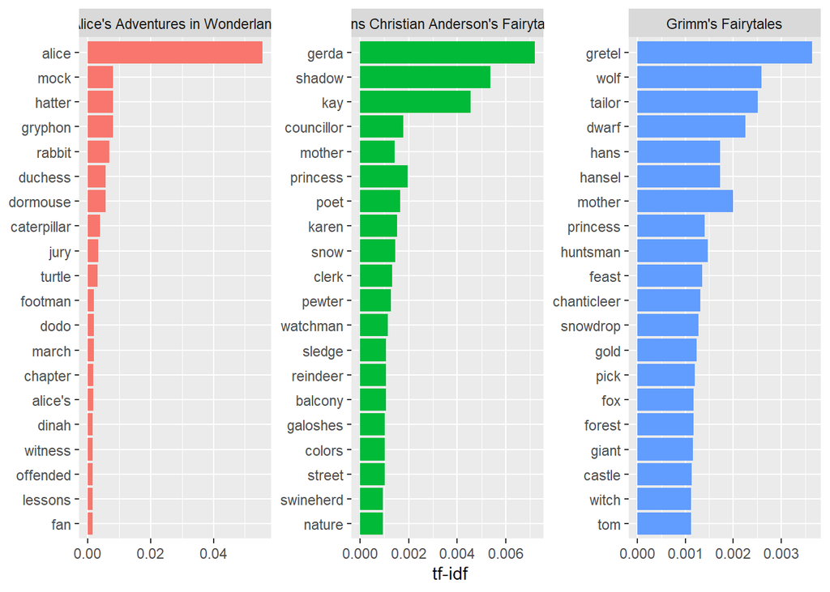

```r
fairytales_idf$word <- as.factor(fairytales_idf$word)

fairytales_idf %>%
  group_by(gutenberg_id) %>%
  arrange(desc(tf_idf)) %>%
  top_n(20, tf_idf) %>%
  ggplot(aes(x = reorder(word, tf_idf), y = tf_idf, fill = gutenberg_id)) +
  geom_col(show.legend = FALSE) +
  labs(x = NULL, y = "tf-idf") +
  facet_wrap(~gutenberg_id, scales = "free") +
  coord_flip()
```

#### Characteristic words per chapter

tf_idf can also be used to find characteristic words per chapter, or any other text unit. We’ll only use “Alice in Wonderland” as an example since it consists of several chapters.  
We first need to create a column that contains the chapter the word came from. The code below:

- finds “chapter” followed by a Roman numeral by using a regular expression regex(“^chapter [\divclx]” in the str_detect() command
- extracts the chapter number by counting how often this regex is found with cumsum(). This is basically a counter that starts at 0 if the regex isn’t matched, then counts up by one every time chapter + Roman numeral is found in the text
- write it to a new column called “chapter”
- also preserves the original line numbers (optional)  
  We then remove the gutenberg_id column, words from chapter 0, i.e. the title and information on the edition, unnest tokens, and remove stopwords.

```r
alice <- fairytales_raw %>%
  filter(gutenberg_id == "Alice's Adventures in Wonderland") %>%
  mutate(linenumber = row_number(),
         chapter = cumsum(str_detect(text, regex("^chapter [\\divclx]",
                                                 ignore_case = TRUE)))) %>%
  select(-gutenberg_id) %>%
  filter(chapter != 0) %>%
  mutate(chapter = as_factor(chapter)) %>%
  unnest_tokens(word, text) %>%
  anti_join(stop_words)
head(alice); summary(alice$chapter)
```

```
## # A tibble: 6 x 3
##   linenumber chapter word
##        <int> <fct>   <chr>
## 1         10 1       chapter
## 2         10 1       rabbit
## 3         10 1       hole
## 4         12 1       alice
## 5         12 1       beginning
## 6         12 1       tired
```

```
##   1   2   3   4   5   6   7   8   9  10  11  12
## 579 571 501 731 557 718 666 715 682 667 586 637
```

Now let’s calculate the tf-idf per chapter:

- first step is to calculate the frequency for each word per chapter
- then apply bind_tf_idf function
- show words with the highest tf_idf

```r
alice <- alice %>%
  group_by(chapter) %>%
  count(word, sort = TRUE)

alice_idf <- alice %>%
  bind_tf_idf(word, chapter, n)

alice_idf %>%
  select(chapter, word, tf_idf) %>%
  arrange(desc(tf_idf))
```

```
## # A tibble: 4,304 x 3
## # Groups:   chapter [12]
##    chapter word        tf_idf
##    <fct>   <chr>        <dbl>
##  1 7       dormouse    0.0699
##  2 7       hatter      0.0666
##  3 5       caterpillar 0.0622
##  4 10      turtle      0.0603
##  5 10      mock        0.0582
##  6 9       turtle      0.0549
##  7 5       pigeon      0.0535
##  8 9       mock        0.0528
##  9 10      gryphon     0.0511
## 10 11      hatter      0.0497
## # ... with 4,294 more rows
```

Again, we can visualise the most characteristic words, this time per chapter:

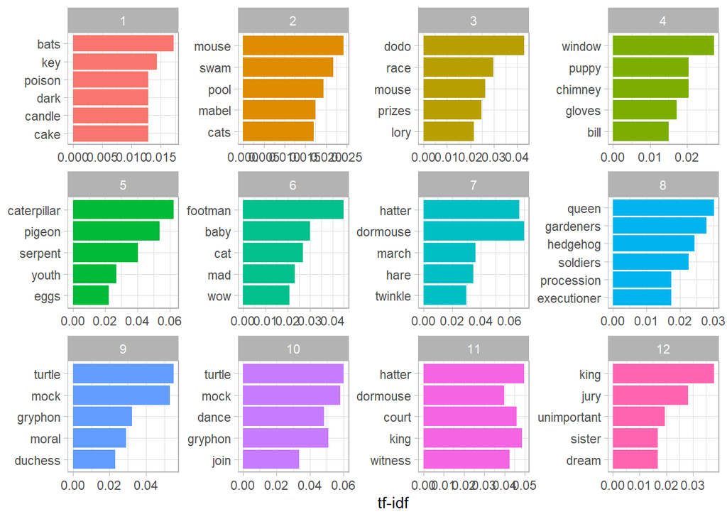

```r
alice_idf %>%
  group_by(chapter) %>%
  arrange(desc(tf_idf)) %>%
  top_n(5, tf_idf) %>%
  ggplot(aes(reorder(word, tf_idf), tf_idf, fill = chapter)) +
  geom_col(show.legend = FALSE) +
  theme_light() +
  labs(x = NULL, y = "tf-idf") +
  facet_wrap(~ chapter, scales = "free") +
  coord_flip()
```